# automatization_notebook_01

2024-10-29

# Чтение данных

В вашем варианте нужно использовать датасеты cardio_train_big или cardio_train_not_too_big.

```r
cardio_train_not_too_big <- read_csv2("data/raw/cardio_train_not_too_big.csv")
```

```
## ℹ Using "','" as decimal and "'.'" as grouping mark. Use `read_delim()` for more control.
```

```r
cardio_train_not_too_big |> head()
```

| id | age | gender | height | weight | ap_hi | ap_lo | cholesterol | gluc | smoke | alco | active | cardio |
| --- | --- | --- | --- | --- | --- | --- | --- | --- | --- | --- | --- | --- |
| 0 | 18393 | 2 | 168 | 62 | 110 | 80 | 1 | 1 | 0 | 0 | 1 | 0 |
| 1 | 20228 | 1 | 156 | 85 | 140 | 90 | 3 | 1 | 0 | 0 | 1 | 1 |
| 2 | 18857 | 1 | 165 | 64 | 130 | 70 | 3 | 1 | 0 | 0 | 0 | 1 |
| 3 | 17623 | 2 | 169 | 82 | 150 | 100 | 1 | 1 | 0 | 0 | 1 | 1 |
| 4 | 17474 | 1 | 156 | 56 | 100 | 60 | 1 | 1 | 0 | 0 | 0 | 0 |
| 8 | 21914 | 1 | 151 | 67 | 120 | 80 | 2 | 2 | 0 | 0 | 0 | 0 |

# Выведите общее описание данных

```r
cardio_train_not_too_big |>
  summary()
```

```
##        id             age            gender          height
##  Min.   :  0.0   Min.   :14321   Min.   :1.000   Min.   : 76.0
##  1st Qu.:116.2   1st Qu.:18067   1st Qu.:1.000   1st Qu.:158.0
##  Median :230.5   Median :19765   Median :1.000   Median :165.0
##  Mean   :234.0   Mean   :19577   Mean   :1.392   Mean   :164.5
##  3rd Qu.:351.8   3rd Qu.:21707   3rd Qu.:2.000   3rd Qu.:170.0
##  Max.   :477.0   Max.   :23613   Max.   :2.000   Max.   :188.0
##      weight           ap_hi           ap_lo          cholesterol
##  Min.   : 45.00   Min.   : 80.0   Min.   :  60.00   Min.   :1.000
##  1st Qu.: 63.25   1st Qu.:120.0   1st Qu.:  80.00   1st Qu.:1.000
##  Median : 71.00   Median :120.0   Median :  80.00   Median :1.000
##  Mean   : 75.41   Mean   :127.9   Mean   :  92.04   Mean   :1.365
##  3rd Qu.: 82.00   3rd Qu.:140.0   3rd Qu.:  90.00   3rd Qu.:2.000
##  Max.   :655.00   Max.   :190.0   Max.   :1100.00   Max.   :3.000
##       gluc           smoke             alco             active
##  Min.   :1.000   Min.   :0.0000   Min.   :0.00000   Min.   :0.0000
##  1st Qu.:1.000   1st Qu.:0.0000   1st Qu.:0.00000   1st Qu.:1.0000
##  Median :1.000   Median :0.0000   Median :0.00000   Median :1.0000
##  Mean   :1.175   Mean   :0.1053   Mean   :0.03801   Mean   :0.7749
##  3rd Qu.:1.000   3rd Qu.:0.0000   3rd Qu.:0.00000   3rd Qu.:1.0000
##  Max.   :3.000   Max.   :1.0000   Max.   :1.00000   Max.   :1.0000
##      cardio
##  Min.   :0.0000
##  1st Qu.:0.0000
##  Median :1.0000
##  Mean   :0.5292
##  3rd Qu.:1.0000
##  Max.   :1.0000
```

**Features:**

*#from kaggle :#* 0 = no 1= yes

df.smoke.unique() [‘no’, ‘yes’]

Categories (2, object): [‘no’, ‘yes’] df.alco.unique() [‘no’, ‘yes’]

cholesterol_map = {1: ‘normal’, 2: ‘above normal’, 3: ‘well above normal’} glucose_map={1: ‘normal’, 2: ‘above average’, 3: ‘well above normal’}

active_map={0:‘no’,1:‘yes’} cvd_map={0:‘no’,1:‘yes’} gender_map={1:‘female’,2:‘male’}

# Очистка данных

1. Уберите переменные, в которых пропущенных значений больше 20% или уберите субъектов со слишком большим количеством пропущенных значений. Или совместите оба варианта. Напишите обоснование, почему вы выбрали тот или иной вариант:

**Обоснование**: В моем варианте нет пропущенных значений ни в одном из датафраймов.

2. Переименуйте переменные в человекочитаемый вид (что делать с пробелами в названиях?);
3. В соответствии с описанием данных приведите переменные к нужному типу (numeric или factor);
4. Отсортируйте данные по возрасту по убыванию;
5. Сохраните в файл outliers.csv субъектов, которые являются выбросами (например, по правилу трёх сигм) — это необязательное задание со звёздочкой;
6. Присвойте получившийся датасет переменной “cleaned_data”.

```r
#1.

sum(is.na(cardio_train_not_too_big))
```

```
## [1] 0
```

# Сколько осталось переменных?

Столько же

# Сколько осталось случаев?

Столько же

```r
#3.
numeric_vars <- c("id","age", "height", "weight", "ap_hi", "ap_lo")
factor_vars <- c("gender", "cholesterol", "alco", "smoke", "active", "cardio", "gluc")

cardio_train_not_too_big <- cardio_train_not_too_big %>%
  mutate(across(all_of(numeric_vars), as.numeric),
         across(all_of(factor_vars), as.factor))
```

# Есть ли в данных идентичные строки?

Нет

```r
identical_rows_not_too_big <- cardio_train_not_too_big %>%
  filter(duplicated(.))

print(identical_rows_not_too_big)
```

```
## # A tibble: 0 × 13
## # ℹ 13 variables: id <dbl>, age <dbl>, gender <fct>, height <dbl>,
## #   weight <dbl>, ap_hi <dbl>, ap_lo <dbl>, cholesterol <fct>, gluc <fct>,
## #   smoke <fct>, alco <fct>, active <fct>, cardio <fct>
```

```r
#2.
new_names <- c(
  `ID` = "id",
  `Возраст` = "age",
  `Пол` = "gender",
  `Рост` = "height",
  `Вес` = "weight",
  `СистолическоеАД` = "ap_hi",
  `ДиастолическоеАД` = "ap_lo",
  `Холестерин` = "cholesterol",
  `Уровень_глюкозы` = "gluc",
  `Курение` = "smoke",
  `Алкоголь` = "alco",
  `Физическая_активность` = "active",
  `Сердечно_сосудистые_заболевания` = "cardio"
)

cardio_train_not_too_big <- cardio_train_not_too_big %>% rename(any_of(new_names))
cardio_train_not_too_big |> head()
```

| ID | Возраст | Пол | Рост | Вес | СистолическоеАД | ДиастолическоеАД | Холестерин | Уровень_глюкозы | Курение | Алкоголь | Физическая_активность | Сердечно_сосудистые_заболевания |
| --- | --- | --- | --- | --- | --- | --- | --- | --- | --- | --- | --- | --- |
| 0 | 18393 | 2 | 168 | 62 | 110 | 80 | 1 | 1 | 0 | 0 | 1 | 0 |
| 1 | 20228 | 1 | 156 | 85 | 140 | 90 | 3 | 1 | 0 | 0 | 1 | 1 |
| 2 | 18857 | 1 | 165 | 64 | 130 | 70 | 3 | 1 | 0 | 0 | 0 | 1 |
| 3 | 17623 | 2 | 169 | 82 | 150 | 100 | 1 | 1 | 0 | 0 | 1 | 1 |
| 4 | 17474 | 1 | 156 | 56 | 100 | 60 | 1 | 1 | 0 | 0 | 0 | 0 |
| 8 | 21914 | 1 | 151 | 67 | 120 | 80 | 2 | 2 | 0 | 0 | 0 | 0 |

```r
#4 + 6

cleaned_data <- cardio_train_not_too_big %>%
  arrange(desc(`Возраст`))
head(cleaned_data)
```

| ID | Возраст | Пол | Рост | Вес | СистолическоеАД | ДиастолическоеАД | Холестерин | Уровень_глюкозы | Курение | Алкоголь | Физическая_активность | Сердечно_сосудистые_заболевания |
| --- | --- | --- | --- | --- | --- | --- | --- | --- | --- | --- | --- | --- |
| 422 | 23613 | 2 | 181 | 99 | 130 | 90 | 1 | 1 | 0 | 0 | 1 | 1 |
| 95 | 23589 | 1 | 155 | 57 | 120 | 80 | 1 | 1 | 0 | 0 | 1 | 1 |
| 200 | 23470 | 2 | 166 | 69 | 130 | 90 | 2 | 1 | 0 | 0 | 1 | 1 |
| 327 | 23444 | 1 | 158 | 69 | 120 | 80 | 1 | 1 | 0 | 0 | 1 | 0 |
| 97 | 23433 | 1 | 156 | 58 | 110 | 70 | 1 | 1 | 0 | 0 | 1 | 0 |
| 458 | 23407 | 1 | 176 | 63 | 160 | 1000 | 2 | 2 | 0 | 0 | 0 | 1 |

```r
#5.
numeric_vars <- c("Возраст", "Рост", "Вес", "СистолическоеАД", "ДиастолическоеАД")
factor_vars_ru <- c("Пол", "Холестерин", "Алкоголь", "Курение", "Физическая_активность", "Уровень_глюкозы")

find_outliers <- function(data, numeric_vars) {
  data %>%
    filter(if_any(all_of(numeric_vars), ~ . < mean(.) - 3 * sd(.) | . > mean(.) + 3 * sd(.)))
}

outliers <- find_outliers(cleaned_data, numeric_vars)

write.csv(outliers, "outliers.csv", row.names = FALSE)
```

# Описательные статистики

## Количественные переменные

1. Рассчитайте для всех количественных переменных для каждой группы (наличие или отсутствие сердечно-сосудистых заболеваний):

1.1) Количество значений;

1.2) Количество пропущенных значений;

1.3) Среднее;

1.4) Медиану;

1.5) Стандартное отклонение;

1.6) 25% квантиль и 75% квантиль;

1.7) Интерквартильный размах;

1.8) Минимум;

1.9) Максимум;

1.10) 95% ДИ для среднего - задание со звёздочкой.

```r
statistics <- list(
  `Количество значений` = ~sum(!is.na(.x)) %>% as.character(),
  `Количество пропущенных значений` = ~sum(is.na(.x)) %>% as.character(),
  `Среднее` = ~mean(.x, na.rm = TRUE) %>% round(2) %>% as.character(),
  `Медиана` = ~median(.x, na.rm = TRUE) %>% round(2) %>% as.character(),
  `Стандартное отклонение` = ~sd(.x, na.rm = TRUE) %>% round(2) %>% as.character(),
  `25% квантиль` = ~quantile(.x, 0.25, na.rm = TRUE) %>% round(2) %>% as.character(),
  `75% квантиль` = ~quantile(.x, 0.75, na.rm = TRUE) %>% round(2) %>% as.character(),
  `95% ДИ нижний` = ~round(mean(.x, na.rm = TRUE) - 1.96 * sd(.x, na.rm = TRUE) / sqrt(sum(!is.na(.x))), 2) %>% as.character(),
  `95% ДИ верхний` = ~round(mean(.x, na.rm = TRUE) + 1.96 * sd(.x, na.rm = TRUE) / sqrt(sum(!is.na(.x))), 2) %>% as.character(),
  `Минимум` = ~min(.x, na.rm = TRUE) %>% round(2) %>% as.character(),
  `Максимум` = ~max(.x, na.rm = TRUE) %>% round(2) %>% as.character()
)


desc_statistics <- cleaned_data %>%
  select(Сердечно_сосудистые_заболевания, all_of(numeric_vars)) %>%
  group_by(Сердечно_сосудистые_заболевания) %>%
  summarise(across(all_of(numeric_vars), statistics), .groups = "drop") %>%
  pivot_longer(cols = -Сердечно_сосудистые_заболевания, names_to = c("Переменная", "Статистика"),
               names_sep = "_", values_to = "Значение") %>%
  pivot_wider(names_from = Переменная, values_from = Значение)


desc_statistics_group_0 <- desc_statistics %>%
  filter(Сердечно_сосудистые_заболевания == 0) %>%
  select(-Сердечно_сосудистые_заболевания)

desc_statistics_group_1 <- desc_statistics %>%
  filter(Сердечно_сосудистые_заболевания == 1) %>%
  select(-Сердечно_сосудистые_заболевания)

head(desc_statistics_group_0)
```

| Статистика | Возраст | Рост | Вес | СистолическоеАД | ДиастолическоеАД |
| --- | --- | --- | --- | --- | --- |
| Количество значений | 161 | 161 | 161 | 161 | 161 |
| Количество пропущенных значений | 0 | 0 | 0 | 0 | 0 |
| Среднее | 18871.21 | 164.08 | 71.16 | 119.3 | 77.52 |
| Медиана | 18987 | 164 | 69 | 120 | 80 |
| Стандартное отклонение | 2490.69 | 11.12 | 14.23 | 12.67 | 8.22 |
| 25% квантиль | 16799 | 158 | 60 | 110 | 70 |

```r
head(desc_statistics_group_1)
```

| Статистика | Возраст | Рост | Вес | СистолическоеАД | ДиастолическоеАД |
| --- | --- | --- | --- | --- | --- |
| Количество значений | 181 | 181 | 181 | 181 | 181 |
| Количество пропущенных значений | 0 | 0 | 0 | 0 | 0 |
| Среднее | 20205.3 | 164.78 | 79.19 | 135.5 | 104.96 |
| Медиана | 20593 | 165 | 73 | 140 | 85 |
| Стандартное отклонение | 2226.44 | 8.07 | 45.56 | 16.74 | 132.45 |
| 25% квантиль | 18807 | 159 | 67 | 120 | 80 |

## Категориальные переменные

1. Рассчитайте для всех категориальных переменных для каждой группы (наличие или отсутствие сердечно-сосудистых заболеваний):

1.1) Абсолютное количество;

1.2) Относительное количество внутри группы;

1.3) 95% ДИ для доли внутри группы - задание со звёздочкой.

```r
categorical_stats <- cleaned_data %>%
  select(Сердечно_сосудистые_заболевания, all_of(factor_vars_ru)) %>%
  pivot_longer(cols = -Сердечно_сосудистые_заболевания, names_to = "Переменная", values_to = "Значение") %>%
  count(Сердечно_сосудистые_заболевания, Переменная, Значение) %>%
  group_by(Сердечно_сосудистые_заболевания, Переменная) %>%
  mutate(
    `Процент по группе` = (n / sum(n) * 100) %>% round(2) %>% str_c('%')
  ) %>%
  ungroup() %>%
  group_by(Переменная, Значение) %>%
  mutate(
    `Процент по выборке` = (n / sum(n) * 100) %>% round(2) %>% str_c('%')
  ) %>%
  ungroup()

categorical_stats
```

| Сердечно_сосудистые_заболевания | Переменная | Значение | n | Процент по группе | Процент по выборке |
| --- | --- | --- | --- | --- | --- |
| 0 | Алкоголь | 1 | 8 | 4.97% | 61.54% |
| 0 | Алкоголь | 0 | 153 | 95.03% | 46.5% |
| 0 | Курение | 1 | 18 | 11.18% | 50% |
| 0 | Курение | 0 | 143 | 88.82% | 46.73% |
| 0 | Пол | 1 | 93 | 57.76% | 44.71% |
| 0 | Пол | 2 | 68 | 42.24% | 50.75% |
| 0 | Уровень_глюкозы | 1 | 145 | 90.06% | 48.49% |
| 0 | Уровень_глюкозы | 2 | 11 | 6.83% | 42.31% |
| 0 | Уровень_глюкозы | 3 | 5 | 3.11% | 29.41% |
| 0 | Физическая_активность | 1 | 124 | 77.02% | 46.79% |

[output cut: 18 more lines]

# Визуализация

## Количественные переменные

1. Для каждой количественной переменной сделайте боксплоты по группам. Расположите их либо на отдельных рисунках, либо на одном, но читаемо;
2. Наложите на боксплоты beeplots - задание со звёздочкой.
3. Раскрасьте боксплоты с помощью библиотеки RColorBrewer.

```r
theme_custom2 <- theme(
    panel.background = element_rect(fill = "white"),
    plot.title = element_text(size = 15, hjust = 0.5),
    axis.text = element_text(size = 12),
    axis.title = element_text(size = 12),
    legend.title = element_text(size = 15),
    legend.text = element_text(size = 11),
    legend.position = "right",
    legend.box = "horizontal"
    )

cleaned_data2 <- anti_join(cleaned_data, outliers)
```

[output not shown]

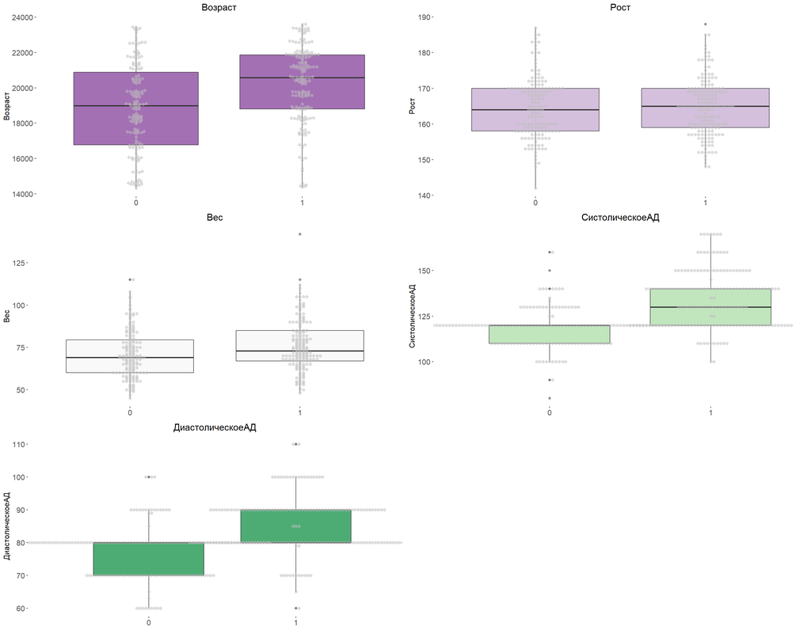

```r
colors <- brewer.pal(n = length(numeric_vars), name = "PRGn")

plots <- list()

for (i in seq_along(numeric_vars)) {
  var <- numeric_vars[i]

  p <- ggplot(cleaned_data2,
              aes_string(x = "as.factor(Сердечно_сосудистые_заболевания)", y = var)) +
    geom_boxplot(fill = colors[i],
                 alpha = 0.7) +
    geom_beeswarm(size = 2,
                  color = "grey",
                  alpha = 0.5) +
    labs(title = var,
         x = NULL,
         y = var) +
    theme_custom2

  plots[[i]] <- p
}
cardio_vis <- ggarrange(plotlist = plots, ncol = 2, nrow = 3)

cardio_vis
```

## Категориальные переменные

1. Сделайте подходящие визуализации категориальных переменных. Обоснуйте, почему выбрали именно этот тип.

Мной выбран мозаичный график как наиболее подходящий тип визуализации, так как он позволяет наглядно отразить распределение значений по группам и *одновременно* визуализировать взаимосвязь между переменными.

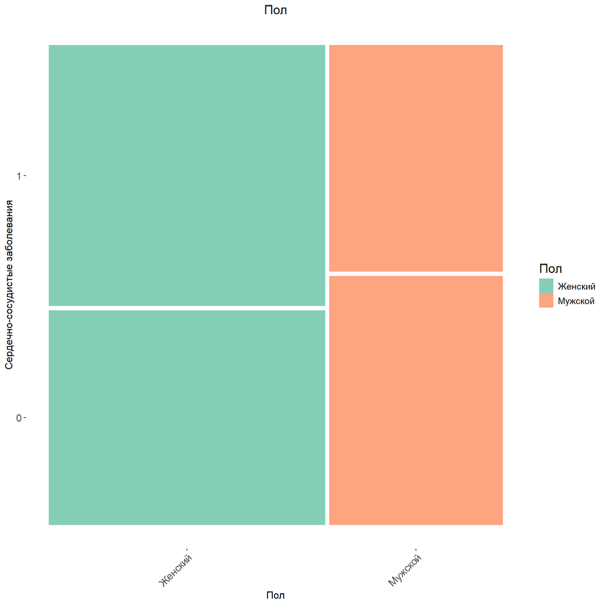

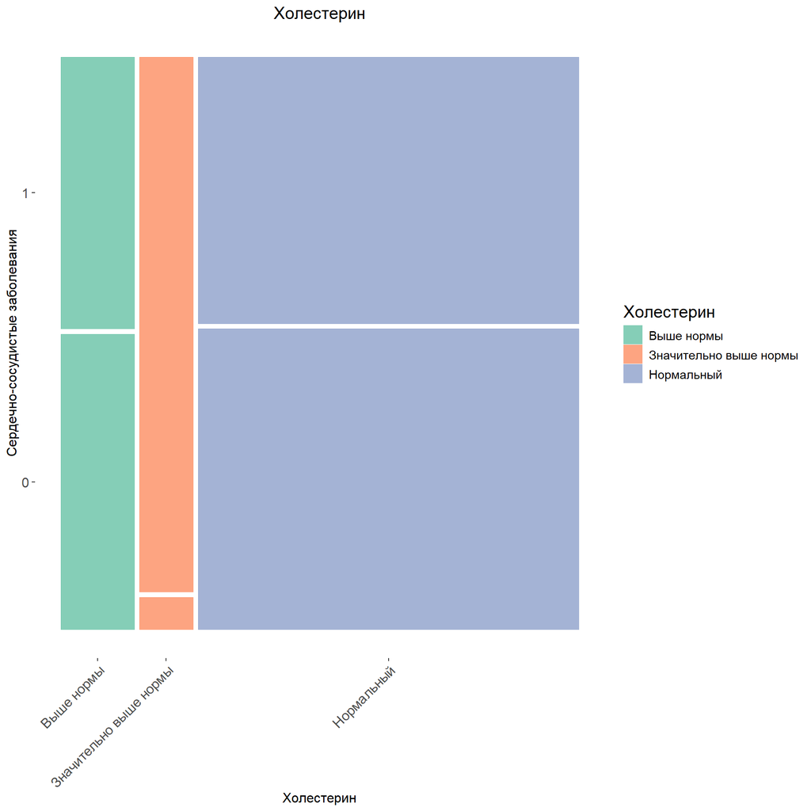

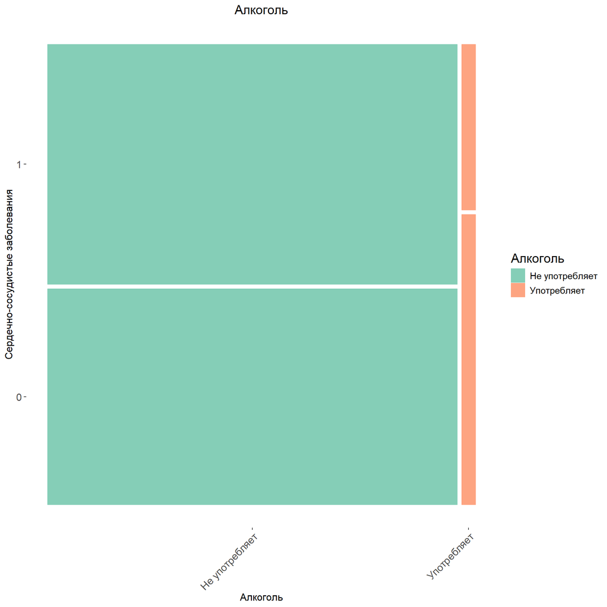

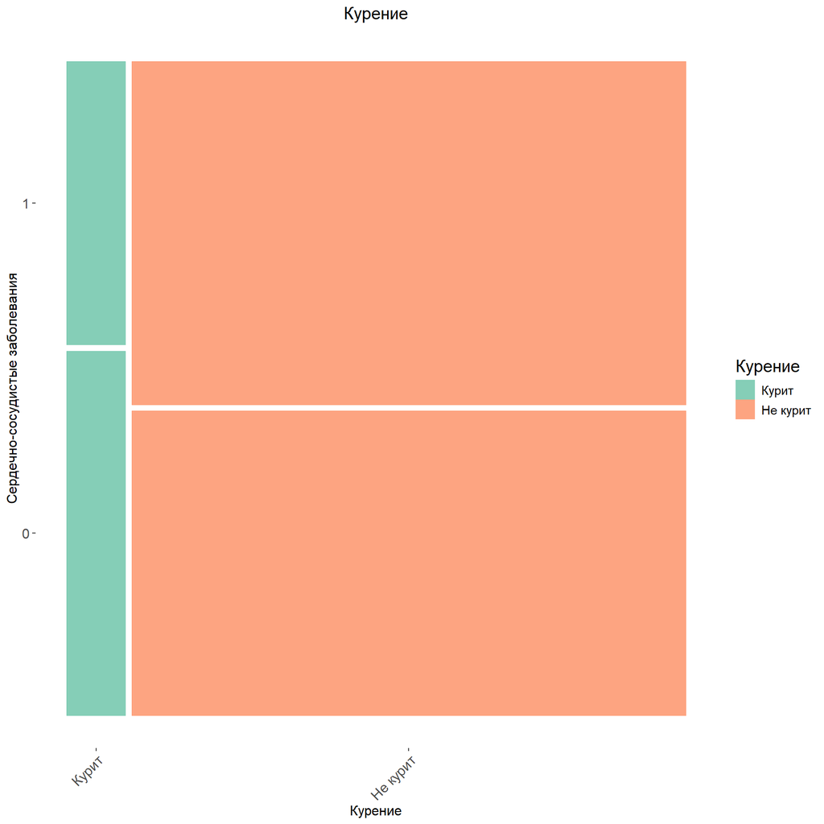

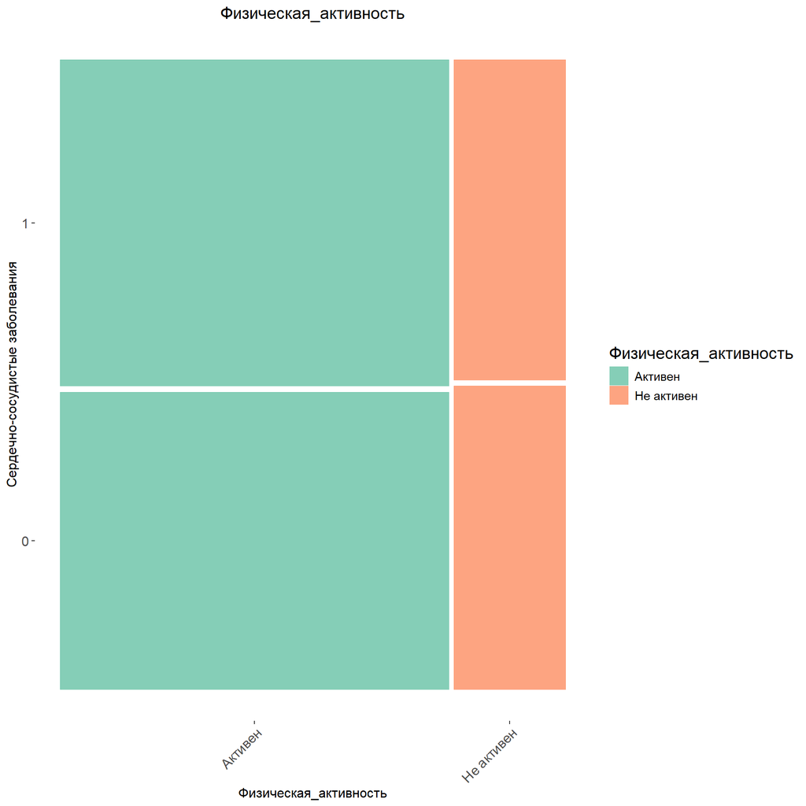

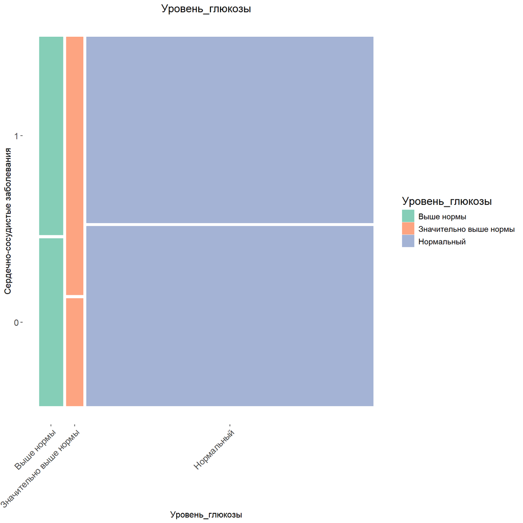

```r
cleaned_data3 <- cleaned_data2 %>%
  mutate(
    Холестерин = factor(case_when(
      Холестерин == 1 ~ "Нормальный",
      Холестерин == 2 ~ "Выше нормы",
      Холестерин == 3 ~ "Значительно выше нормы"
    )),
    Уровень_глюкозы = factor(case_when(
      Уровень_глюкозы == 1 ~ "Нормальный",
      Уровень_глюкозы == 2 ~ "Выше нормы",
      Уровень_глюкозы == 3 ~ "Значительно выше нормы"
    )),
    Пол = factor(ifelse(Пол == 1, "Женский", "Мужской")),
    Алкоголь = factor(ifelse(Алкоголь == 1, "Употребляет", "Не употребляет")),
    Курение = factor(ifelse(Курение == 1, "Курит", "Не курит")),
    Физическая_активность = factor(ifelse(Физическая_активность == 1, "Активен", "Не активен"))
  )

palette_colors <- brewer.pal(n = length(factor_vars_ru), name = "Set2")


for (i in seq_along(factor_vars_ru)) {
  var <- factor_vars_ru[i]

  p <- ggplot(data = cleaned_data3) +
    geom_mosaic(aes(x = product(`Сердечно_сосудистые_заболевания`, !!sym(var)),
                    fill = !!sym(var)), na.rm = TRUE) +
    scale_fill_manual(values = palette_colors) +
    labs(title = paste(var),
         x = paste(var),
         y = "Сердечно-сосудистые заболевания") +
    theme_custom2 +
    theme(
      legend.position = "right",
      plot.title = element_text(hjust = 0.5),
      axis.text.x = element_text(angle = 45, hjust = 1)
    )

  print(p)
}
```

# Статистические оценки

## Проверка на нормальность

1. Оцените каждую переменную на соответствие нормальному распределению с помощью теста Шапиро-Уилка. Какие из переменных являются нормальными и как как вы это поняли?

Тест Шапиро-Уилка оценивает данные из выборки с нулевой гипотезой о том, что набор данных распределен нормально. Все протестированные количественные переменные (возраст, рост, вес, систолическое и диастолическое артериальное давление) не следуют нормальному распределению, так как p-значения для всех переменных заметно меньше 0.05.

```r
shapiro_results <- tibble(Переменная = numeric_vars,
                          p_value = sapply(numeric_vars,
                                           function(var) {
                            shapiro.test(cleaned_data3[[var]])$p.value
                          }))

shapiro_results
```

| Переменная | p_value |
| --- | --- |
| Возраст | 1.713643e-07 |
| Рост | 9.353978e-04 |
| Вес | 2.740595e-07 |
| СистолическоеАД | 1.521294e-11 |
| ДиастолическоеАД | 7.949668e-14 |

```r
#просто посмотреть на распределение
library(gridExtra)
```

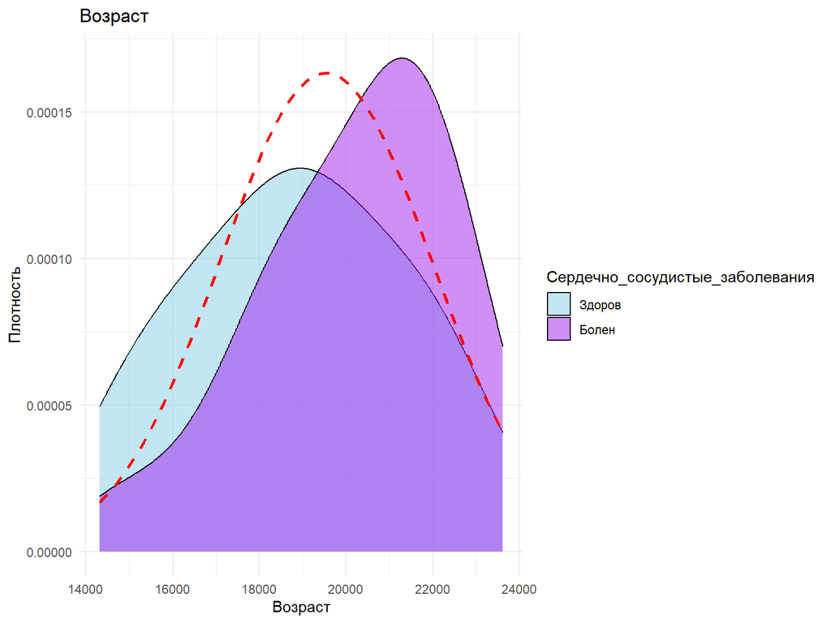

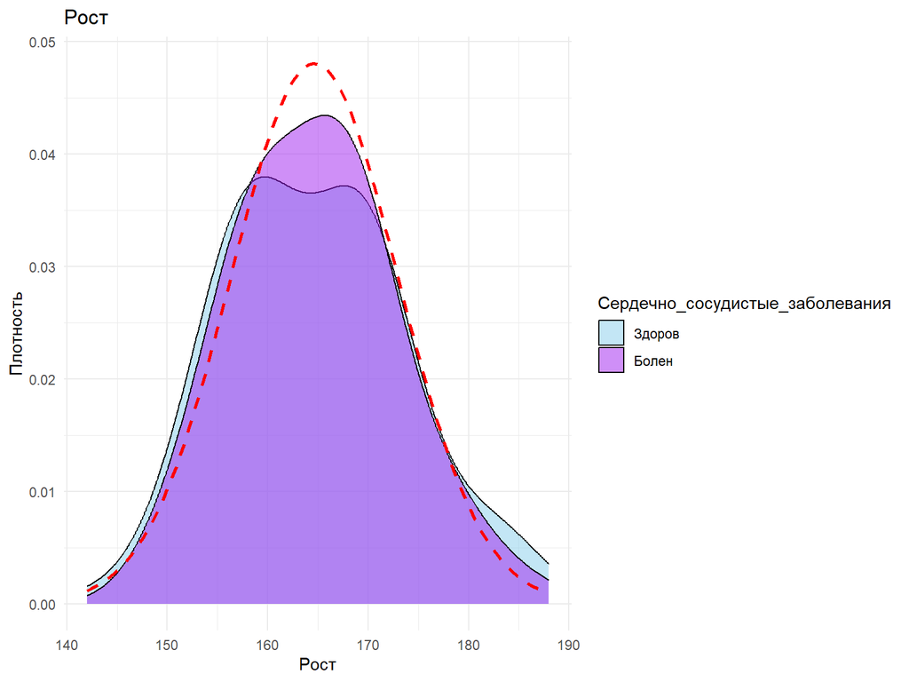

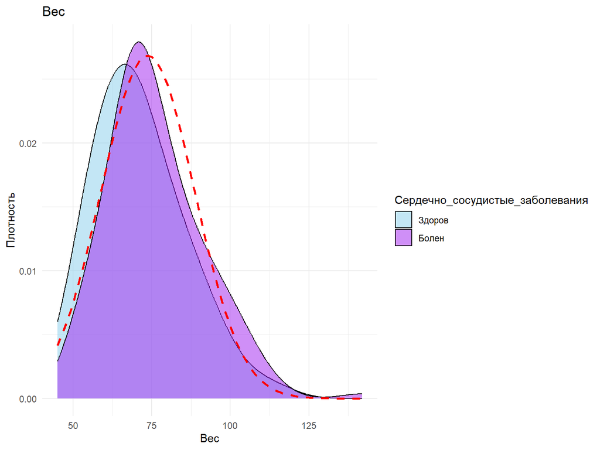

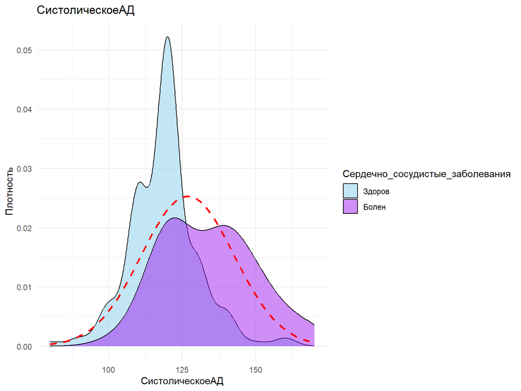

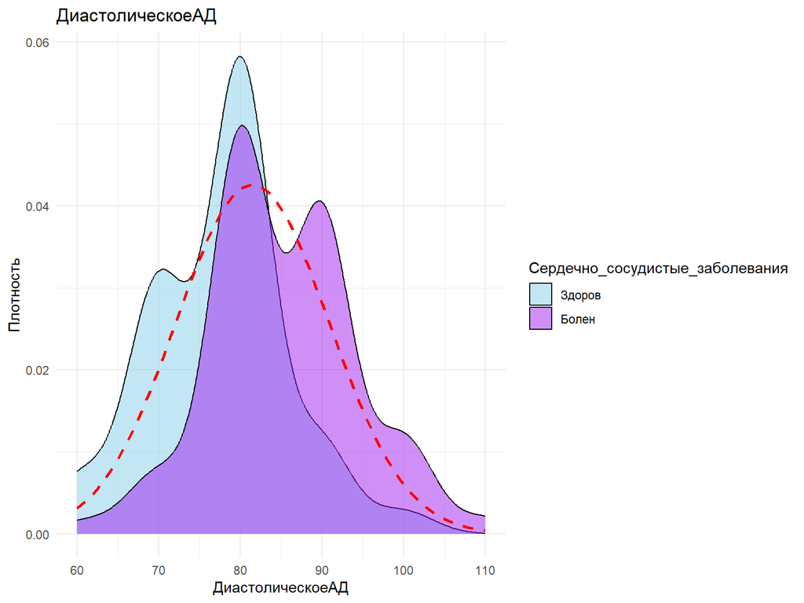

```r
for (i in seq_along(numeric_vars)) {
  var <- numeric_vars[i]

  density_n <- ggplot(cleaned_data2, aes_string(x = var,fill = "as.factor(Сердечно_сосудистые_заболевания)")) +
    geom_density(alpha = 0.5,
                 adjust = 1.5) +
    stat_function(fun = dnorm,
                  args = list(mean = mean(cleaned_data2[[var]],
                                          na.rm = TRUE),
                              sd = sd(cleaned_data2[[var]],
                                      na.rm = TRUE)),
                  color = "red",
                  size = 1,
                  linetype = "dashed") +
    labs(title = paste(var),
         x = var,
         y = "Плотность",
         fill = "Сердечно_сосудистые_заболевания") +
    scale_fill_manual(values = c("0" = "skyblue", "1" = "purple"),
                       labels = c("Здоров", "Болен")) +
    theme_minimal()

  print(density_n)
}
```

2. Постройте для каждой количественной переменной QQ-плот. Отличаются ли выводы от теста Шапиро-Уилка? Какой метод вы бы предпочли и почему?

Заметны сильные отклонения точек на графиках для переменных: возраст,систолическое_АД, диастолическое_АД. Это указывает, что выводы теста Шапиро-Уилка верны, распределение количественных переменных не соответсвует нормальному. Для переменных рост и вес отклонения не так сильны, но распределение также не соответсвует нормальному.

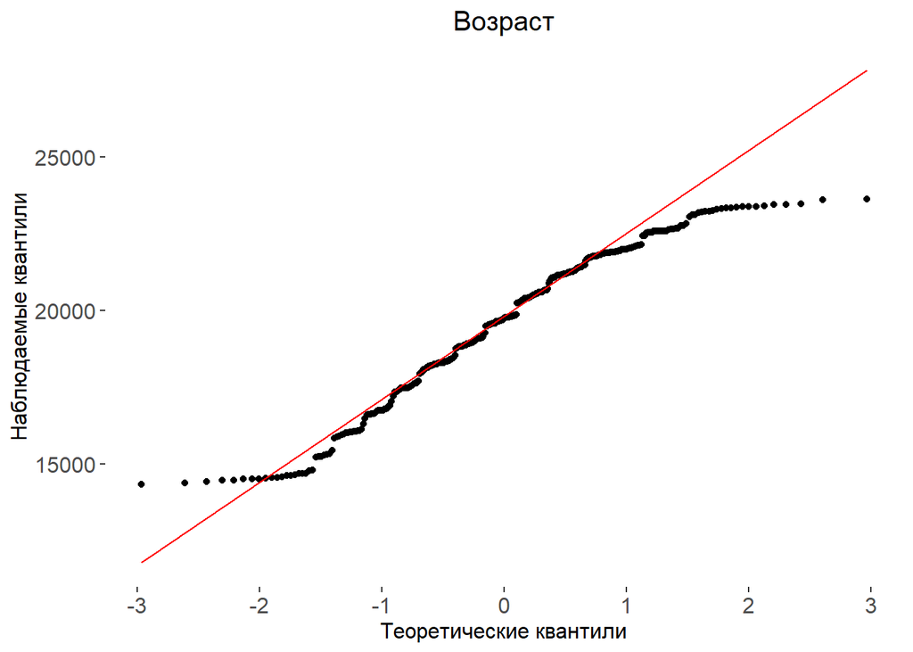

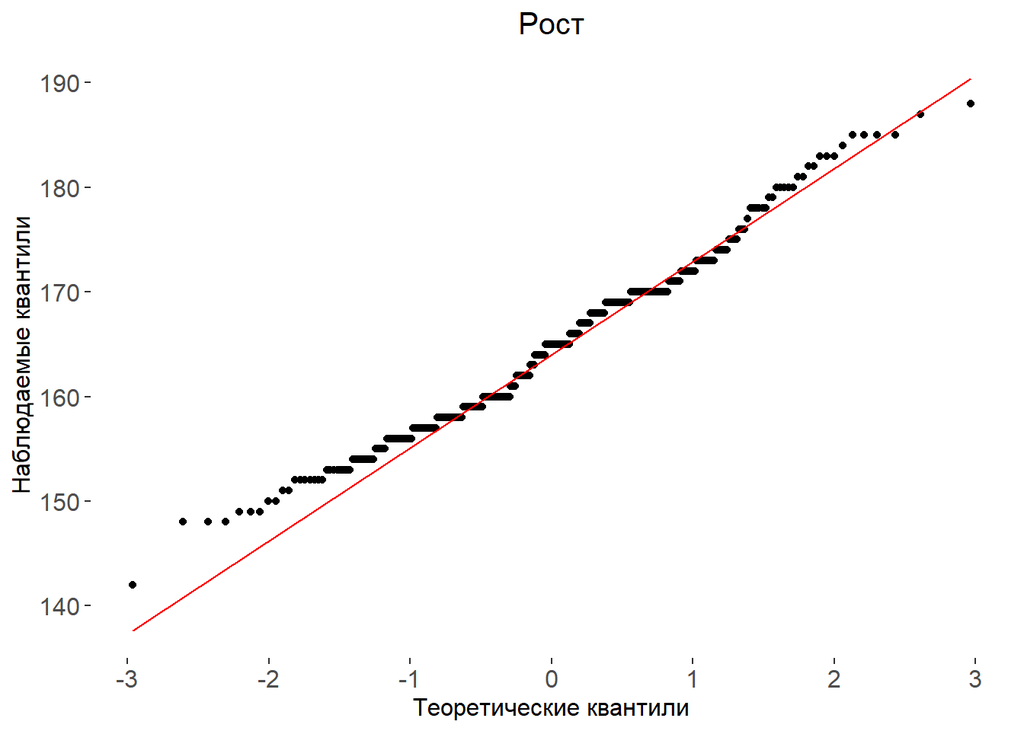

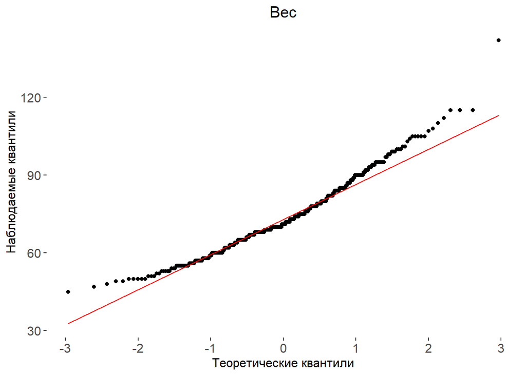

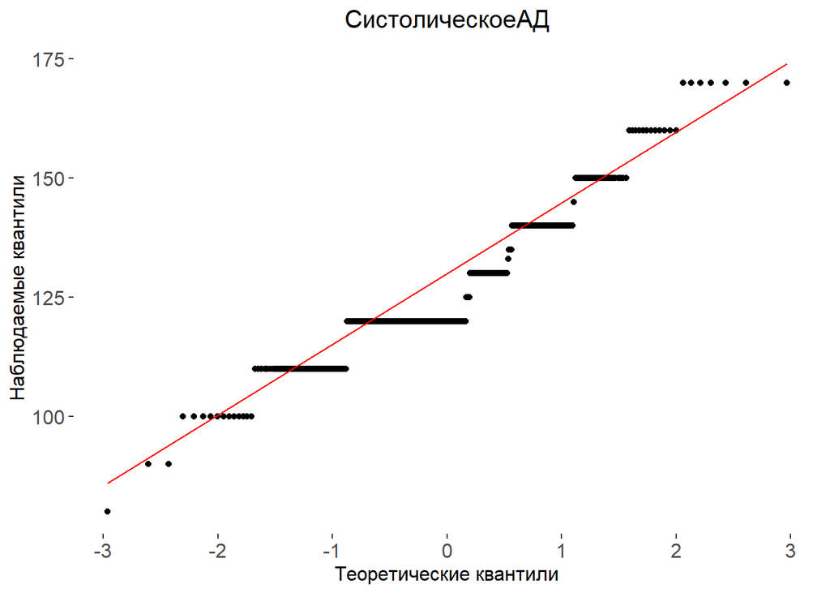

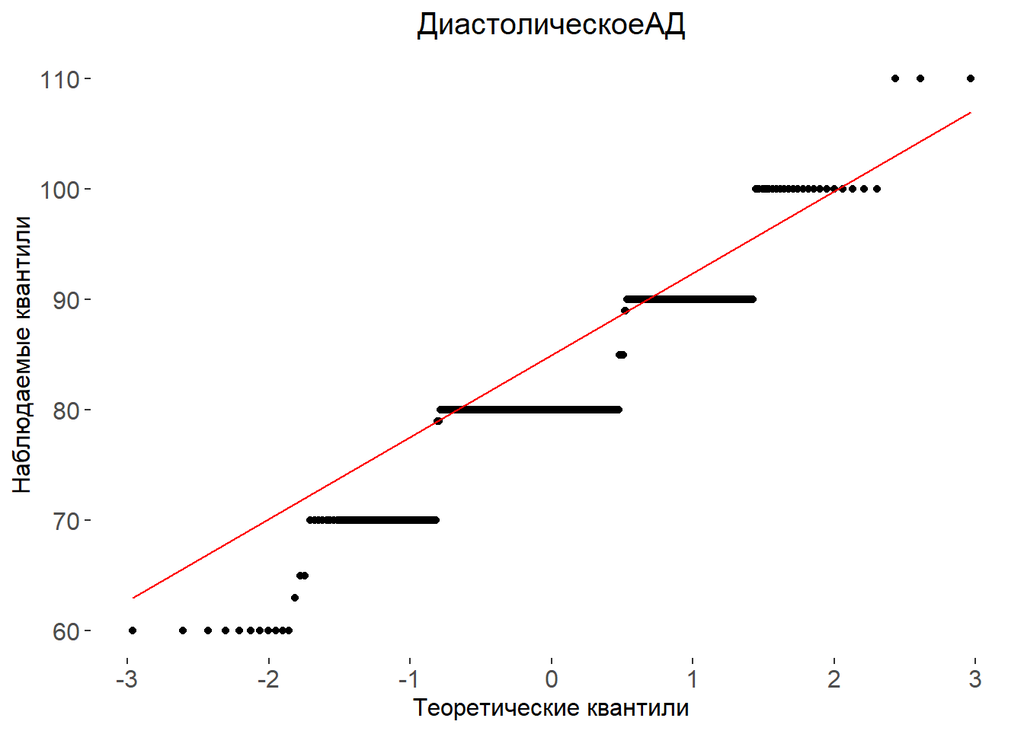

```r
for (var in numeric_vars) {
  QQ_plot <- ggplot(cleaned_data3,
                    aes(sample = .data[[var]])) +
    stat_qq() +
    stat_qq_line(color = "red") +
    labs(title = paste(var),
         x = "Теоретические квантили",
         y = "Наблюдаемые квантили") +
    theme_custom2

  print(QQ_plot)
}
```

3. Ниже напишите, какие ещё методы проверки на нормальность вы знаете и какие у них есть ограничения.

-Тест Колмогорова-Смирнова сравнивает эмпирическое распределение с нормальным, но может быть чувствителен к размеру выборки — при больших данных он иногда выявляет незначительные отклонения как значимые.

-Графические методы, такие как гистограммы и QQ-графики, помогают визуально оценить нормальность, но не дают строгих статистических выводов. Они лучше всего работают в сочетании с числовыми тестами.

-Тест хи-квадрат можно использовать для проверки нормальности, разбивая данные на интервалы и сравнивая частоты с теоретически нормальными. Ограничения: чувствительность к числу интервалов и низкая точность при небольших выборках. Чаще используется для категориальных данных.

## Сравнение групп

1. Сравните группы (переменная **cardio**) по каждой переменной (как количественной, так и категориальной). Для каждой переменной выберите нужный критерий и кратко обоснуйте его выбор в комментариях.

```r
numeric_vars <- c("Возраст", "Рост", "Вес", "СистолическоеАД", "ДиастолическоеАД")
factor_vars <- c("Пол", "Холестерин", "Алкоголь", "Курение", "Физическая_активность", "Уровень_глюкозы")

compare_groups <- function(data, group_var, numeric_vars, categorical_vars) {
  results <- list()

  #тест Манна-Уитни для количественных переменных, распределенных ненормальным образом
  for (num_var in numeric_vars) {
    test <- wilcox.test(reformulate(group_var, response = num_var), data = data)
    results[[num_var]] <- tibble(
      Переменная = num_var,
      Метод = "Манна-Уитни",
      p_value = test$p.value,
      `Статистически значимые различия` = ifelse(test$p.value < 0.05, "Да", "Нет")
    )
  }

  #Хи-квадрат тест для категориальных переменных, т.к. наблюдений много
  for (cat_var in factor_vars) {
    tbl <- table(data[[group_var]], data[[cat_var]])
    test <- chisq.test(tbl)
    results[[cat_var]] <- tibble(
      Переменная = cat_var,
      Метод = "хи-квадрат",
      p_value = test$p.value,
      `Статистически значимые различия` = ifelse(test$p.value < 0.05, "Да", "Нет")
    )
  }

  bind_rows(results)
}

results <- compare_groups(cleaned_data2, "Сердечно_сосудистые_заболевания", numeric_vars, factor_vars)
results
```

| Переменная | Метод | p_value | Статистически значимые различия |
| --- | --- | --- | --- |
| Возраст | Манна-Уитни | 1.643531e-06 | Да |
| Рост | Манна-Уитни | 9.360662e-01 | Нет |
| Вес | Манна-Уитни | 2.546534e-03 | Да |
| СистолическоеАД | Манна-Уитни | 2.397082e-19 | Да |
| ДиастолическоеАД | Манна-Уитни | 6.979095e-15 | Да |
| Пол | хи-квадрат | 2.406115e-01 | Нет |
| Холестерин | хи-квадрат | 8.727005e-07 | Да |
| Алкоголь | хи-квадрат | 4.495447e-01 | Нет |
| Курение | хи-квадрат | 4.181931e-01 | Нет |
| Физическая_активность | хи-квадрат | 9.873126e-01 | Нет |

[output cut: 1 more lines]